# Part II - Ford GoBike System

## Dataset Overview

This dataset includes information about individual bike rides made in a bike sharing system covering the greater San Francisco Bay area.The features in this dataset include duration_sec,start_time,end_time,start_station_name,end_station_name,user_type and member_gender. A significant portion of the original data had been removed during the cleaning process. The cleaned dataset was stored with the name **ford_bk**. I will be using the cleaned dataset **ford_bk** for my presentation below.

## Distribution of rides by User Type

The barchart below shows over 150,000 as the subscriber count and over 15,000 as the customer count. This shows us that the vast majority of the users are from the subscriber base.

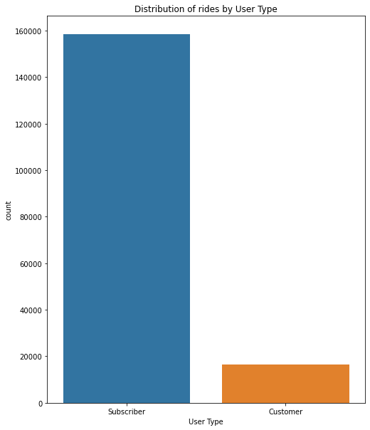

## Distribution of rides by Weekday

From the barchart below I observed that most of the trips were taken on Thursday. I also observed that the weekends (Saturday & Sunday) had the lowest trip count.

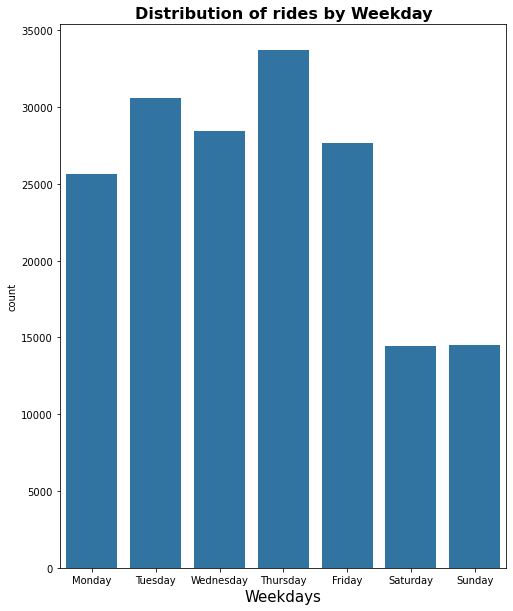

## Distribution of rides by Gender

From the barchart below I observed that the overwhelming majority of users are males.

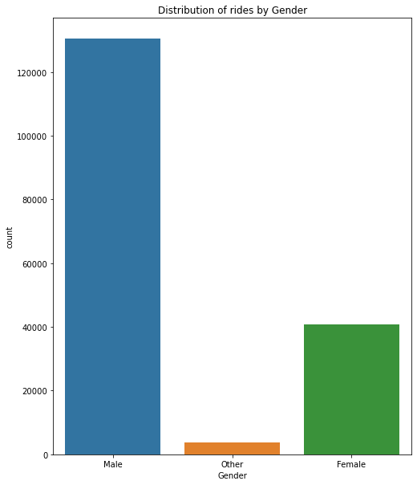

## Trip Duration across Gender Type

I observed that Female users spent more time during rides.

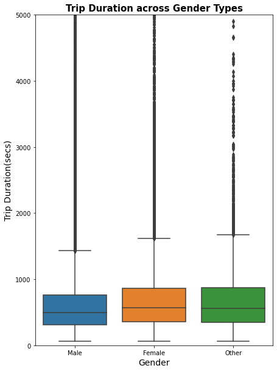

## Trip Duration across User Type

I observed that customers spent more time during rides.

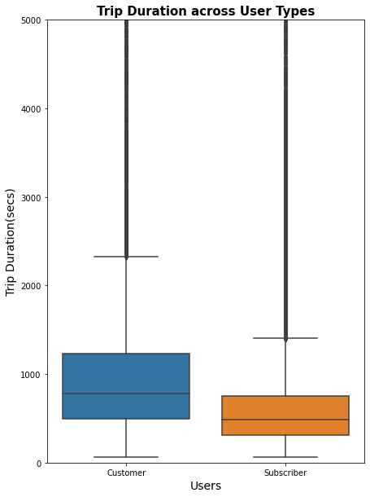